# Reproducing Karin et al’s longitudal model of senescent cell growth

```r
library(dplyr)
library(foreach)
library(ggplot2)
library(latex2exp)
library(purrr)
library(reshape2)
library(stringr)
library(tidyverse)
# Stan-specific stuff
library(rstan)
library(gridExtra)
rstan_options (auto_write = TRUE)
options (mc.cores = parallel::detectCores ())
set.seed(3) # for reproductibility
```

# Loading and visualizing the data

```r
snc_counts_fname <- str_c(
  params$data_dir, "raw", "senescent_cells_and_the_dynamics_of_aging__fig_2.csv",
  sep="/"
)
raw_snc_counts <- read.csv(snc_counts_fname, header=TRUE) %>%
  drop_na()
snc_counts <- melt(
  data = raw_snc_counts,
  id.vars = "mouse.week",
  measure.vars = c(
    "X8", "X16", "X24", "X32", "X40", "X48", "X56", "X64", "X72", "X80"
  ),
  value.name = "TBL_x_10_5"
)
snc_counts <- snc_counts %>%
  rename(week = "variable", mouse = "mouse.week")
snc_counts$week <- map_int(snc_counts$week, function (week) { return(as.integer(substr(week, 2, str_length(week)))) })
max(snc_counts$mouse)
```

```
[1] 32
```

Now we’re going to reproduce Karin et al’s fig. 2a, since it doesn’t require any model-fitting, although we won’t do the nice grey shading they did for now…

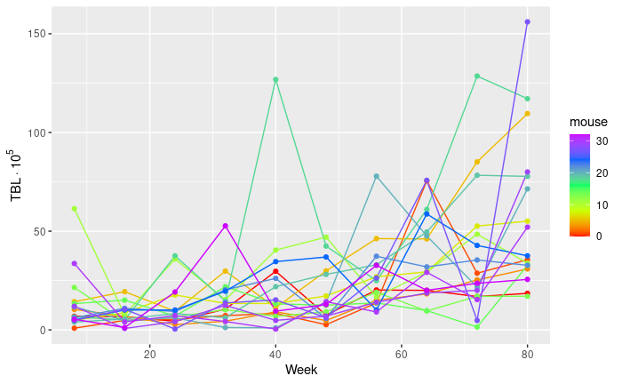

```r
ggplot(
  data = snc_counts,
  aes(x = week, y = TBL_x_10_5, color = mouse, group = mouse)
) +
  xlab("Week") + ylab(TeX("$ TBL \\times 10^5 $")) +
  scale_color_gradientn(colours = rainbow(5)) + geom_line() + geom_point()
```

Next we’re going to replicate the first part of Karin et al’s fig 2c, which shows the mean and standard deviation of normalized senescent cell counts at each week time point.

To normalize senescent cell counts, we adjust all counts to make the mean abundance across the first three measured time points – 8, 16, 24 – equal 1. To do so, we set
$$\beta = \frac{1}{3n} \sum_{i=1}^n \sum_{j \in 8, 16, 24} c_{ij} = 1$$
and divide all counts by it. In other words, normalize by the mean abundance from the first three weeks of data.

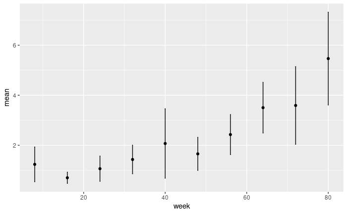

```r
norm_const <- mean(
  snc_counts[snc_counts$week %in% c(8, 16, 24),]$TBL_x_10_5, na.rm = T
)
snc_counts$norm_abundance <- snc_counts$TBL_x_10_5 / norm_const
mean_abundances <- aggregate(
  snc_counts$norm_abundance, list(snc_counts$week), mean, na.rm = T
)$x
stddev_abundances <- aggregate(
  snc_counts$norm_abundance, list(snc_counts$week), sd, na.rm = T
)$x
mean_stddev_abundances <- data.frame(
  mean = mean_abundances,
  stddev = stddev_abundances,
  week = unique(snc_counts$week)
)
p <- ggplot(mean_stddev_abundances, aes(x=week, y=mean)) + geom_point() +
    geom_errorbar(aes(ymin=mean-stddev/2, ymax=mean+stddev/2), width=.2,
                 position=position_dodge(0.05))
print(p)
```

Notably our standard deviation bars seem larger than whatever Karin et al show in their full version of this figure (fig. 2c), but we seem to reproduce their standard error values based on their display of them in fig. 2d.

## Fitting the model

As a way to check we haven’t missed something integral to Karin et al’s work, we’re going to fit a Bayesian version of their SR (Saturated-Removal) model and verify that we (hopefully) approximately reproduce their predictive distribution.

Since they did maximum likelihood estimation (with a grid search I’d add) whereas we’re fitting a full posterior distribution with close-to-noninformative prior, we don’t expect exact matching. Because the likelihood includes an ODE, analytically showing the data dominates the prior goes beyond my abilities, but intuitively I expect the posterior predictive distribution to have approximately the same mean as theirs with wider error bars.

```r
# Time series of SnC counts
mice <- unique(snc_counts$mouse)
weeks <- unique(snc_counts$week)
n_mice <- length(mice)
n_weeks <- length(weeks)
print(n_mice)
```

```
[1] 17
```

```r
snc_abundance <- matrix(nrow = n_mice, ncol=n_weeks)
for (m in 1:n_mice) {
  for (t in 1:n_weeks) {
    week <- weeks[t]
    mouse <- mice[m]
    mouse_week_index <- which(snc_counts$mouse == mouse & snc_counts$week == week)[1]
    snc_abundance[m, t] <- snc_counts$norm_abundance[mouse_week_index]
  }
}

# times
t <- seq(0, n_weeks * 8, by = 8) # 8 hard-coded to match data
t0 = 0
t <- t[-1]

# initial conditions
y0 = c(1)
dim(y0) <- (1)

# data for Stan
data_snc <- list(n_weeks = n_weeks, n_mice = n_mice, y0 = y0, t0 = t0, ts = t, N = N, cells = snc_abundance)

# number of MCMC steps
niter <- 2000
```

```r
model <- stan_model("snc_sr_model.stan")
fit_karin_et_al <- sampling(
  model,
  data = data_snc,
  iter = niter,
  chains = 4
)
```

```
starting worker pid=174668 on localhost:11219 at 09:14:50.189
starting worker pid=174682 on localhost:11219 at 09:14:50.342
starting worker pid=174696 on localhost:11219 at 09:14:50.488
starting worker pid=174710 on localhost:11219 at 09:14:50.639
```

## Diagnosing model fit

```r
pars=c('eta', 'beta', 'eps', 'lp__')
print(fit_karin_et_al, pars = pars)
```

```
Inference for Stan model: snc_sr_model.
4 chains, each with iter=2000; warmup=1000; thin=1;
post-warmup draws per chain=1000, total post-warmup draws=4000.

           mean se_mean   sd    2.5%     25%     50%     75%   97.5% n_eff Rhat
eta[1]     0.36    0.01 0.20    0.04    0.21    0.34    0.49    0.80  1300    1
eta[2]     0.02    0.00 0.01    0.00    0.01    0.02    0.02    0.05  1393    1
beta[1]    1.04    0.01 0.39    0.31    0.76    1.04    1.30    1.86  1402    1
beta[2]    0.53    0.01 0.30    0.10    0.31    0.48    0.69    1.27  1347    1
eps        2.08    0.00 0.11    1.87    2.00    2.07    2.15    2.31  2067    1
lp__    -219.51    0.07 1.98 -224.61 -220.50 -219.10 -218.08 -216.92   831    1

Samples were drawn using NUTS(diag_e) at Wed Dec  2 09:25:07 2020.
For each parameter, n_eff is a crude measure of effective sample size,
and Rhat is the potential scale reduction factor on split chains (at
convergence, Rhat=1).
```

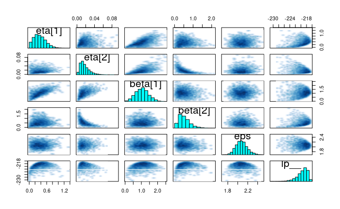

```r
pairs(fit_karin_et_al, pars = pars)
```

[figure not shown]

```r
snc_counts_pred <- cbind(
  as.data.frame(
    summary(
      fit_karin_et_al, pars = "pred_cells_means",
      probs = c(0.025, 0.5, 0.975)
    )$summary
  ),
  t,
  mean_abundances,
  stddev_abundances
)
colnames(snc_counts_pred) <- make.names(colnames(snc_counts_pred)) # to remove % in the col names
head(snc_counts_pred)
```

|  | mean | se_mean | sd | X2.5. | X50. | X97.5. | n_eff | Rhat | t | mean_abundances | stddev_abundances |
| --- | --- | --- | --- | --- | --- | --- | --- | --- | --- | --- | --- |
| pred_cells_means[1] | 0.6517678 | 0.009150094 | 0.5407682 | -0.40764991 | 0.6520607 | 1.680076 | 3492.780 | 1.0001571 | 8 | 1.2364405 | 1.3902218 |
| pred_cells_means[2] | 0.8492163 | 0.009273551 | 0.5444682 | -0.21436961 | 0.8423345 | 1.917427 | 3447.092 | 0.9999946 | 16 | 0.7002483 | 0.4484151 |
| pred_cells_means[3] | 1.1080291 | 0.008602274 | 0.5383820 | 0.03466784 | 1.1099361 | 2.142118 | 3917.008 | 0.9997464 | 24 | 1.0633112 | 1.0090447 |
| pred_cells_means[4] | 1.4109121 | 0.008526951 | 0.5346886 | 0.38344326 | 1.3978920 | 2.474061 | 3932.008 | 1.0005057 | 32 | 1.4314154 | 1.1444940 |
| pred_cells_means[5] | 1.7525842 | 0.008635152 | 0.5502350 | 0.67574493 | 1.7439562 | 2.876907 | 4060.284 | 0.9997111 | 40 | 2.0704870 | 2.7768438 |
| pred_cells_means[6] | 2.1752182 | 0.008895273 | 0.5364478 | 1.13548469 | 2.1699378 | 3.262990 | 3636.942 | 1.0012015 | 48 | 1.6563804 | 1.3224648 |

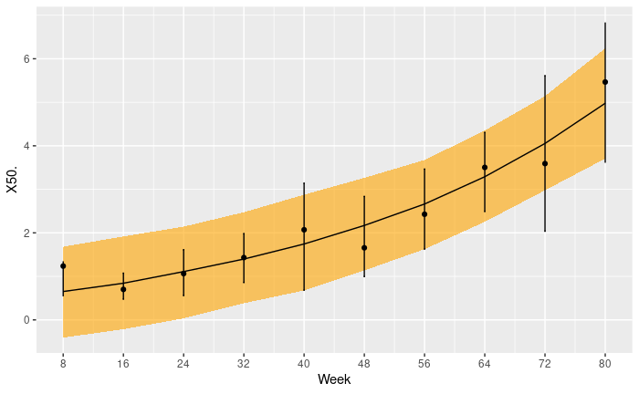

```r
ggplot(snc_counts_pred, mapping = aes(x = t)) +
  geom_ribbon(aes(ymin = X2.5., ymax = X97.5.), fill = "orange", alpha = 0.6) +
  geom_line(mapping = aes(x = t, y = X50.)) +
  geom_point(mapping = aes(y = mean_abundances)) +
  geom_errorbar(
    aes(
      ymin=mean_abundances-stddev_abundances/2,
      ymax=mean+stddev_abundances/2
    ),
    width=.2,
    position=position_dodge(0.05)
  ) +
  scale_x_continuous(name = "Week", breaks=t, labels=t, limits = c(8, 80))
```

```r
  labs(x = "Week", y = "SnC (normalized)")
```

```
$x
[1] "Week"

$y
[1] "SnC (normalized)"

attr(,"class")
[1] "labels"
```